# Missing Data In-Class Activity PS 312

Jaye Seawright

May 12, 2026

Let’s look at whether missing data are a problem in the study of democracy and economic development. With your group, access the Quality of Governance (QoG) dataset, and assemble a regression model predicting countries’ level of democracy based on per capita GDP and any control variables you see as relevant. Are there missing data? What are some possible solutions? Show how implementing a good solution would modify the results (if at all).

Start by loading relevant data:

```r
library(tidyverse)
library(devtools)
#install_github("ropengov/rqog")
library(rqog)
#Download the QOG data:
qog_standard <- read_qog(which_data="standard", data_type = "time-series")
```

```
## Local file not found.
## from http://www.qogdata.pol.gu.se/data/qog_std_ts_jan23.csv
## in file: C:\Users\jnsno\AppData\Local\Temp\RtmpCWQVZU/rqog/qog_std_ts_jan23.csv
## Reading cache file C:\Users\jnsno\AppData\Local\Temp\RtmpCWQVZU/rqog/qog_std_ts_jan23.csv
```

You can consult [the very long codebook](https://www.qogdata.pol.gu.se/data/codebook_std_jan26.pdf) for these data. It’s immediately apparent that a lot of variables are included. There may in fact be too many for your computer to handle missingness during our class period. So your first task is to choose a set of variables for the model you want to estimate in the end. You need a measure of the outcome (democracy), the cause (economic development), and any control variables.

In addition, select a handful of variables you think might be usefully related to the variables in your model in terms of providing information about their values when there is missingness.

At this point, you’re ready to start carrying out your missing-data analysis. Fill in the sample code below with variables that make sense for your analysis. In the example code below, I do this for an analysis focusing on democracy and carbon footprints.

```r
qog_demcarbon_data <- data.frame(carbonfootprint = qog_standard$ef_carb,
                                 democracy = qog_standard$vdem_libdem,
                                 gdp = qog_standard$wdi_gdpcapcon2015,
                                 education = qog_standard$wdi_gerp,
                                 lifeexp = qog_standard$wdi_lifexp,
                                 fossilfuels = qog_standard$wdi_fossil,
                                 corruption = qog_standard$bci_bci,
                                 year = qog_standard$year,
                                 country = qog_standard$cname)
```

Now look at the pattern of missingness in your smaller subset of the data:

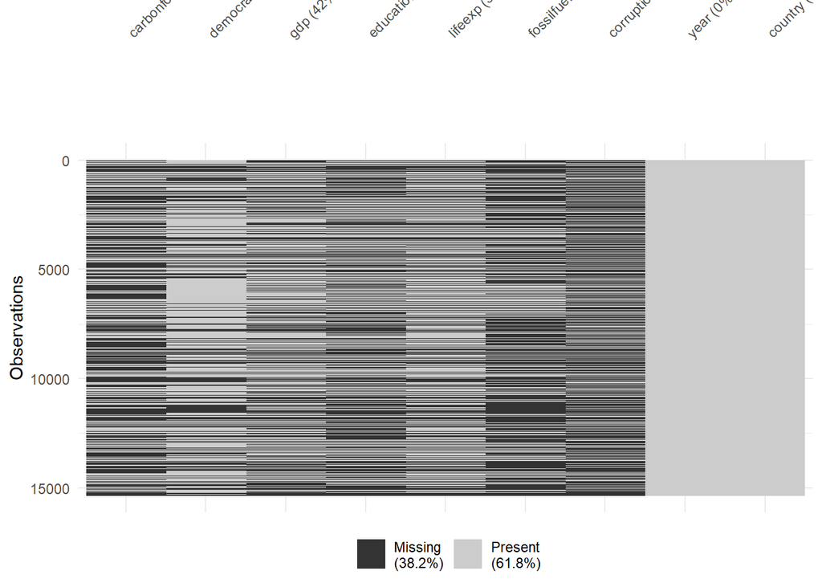

```r
library(naniar)
vis_miss(qog_demcarbon_data)
```

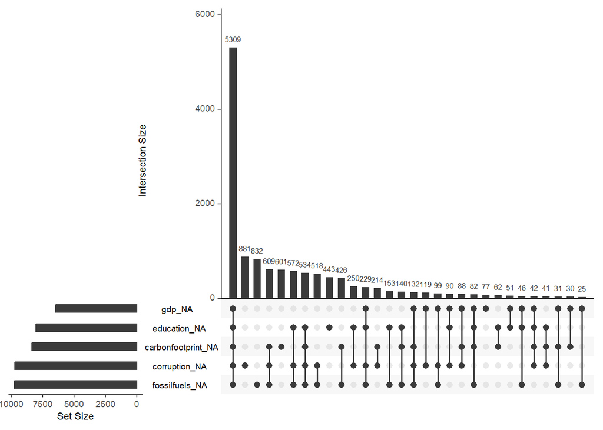

```r
library(UpSetR)
gg_miss_upset(qog_demcarbon_data)
```

What do you conclude? Are there some variables that seem to have more missingness than others? Can you see patterns where certain variables tend to be missing together?

For my data, I notice that there is a large block of observations where all variables are simultaneously missing. They turn out to be clustered in the earlier years, which I remove. You may have a similar problem, or not, depending on your variables. It’s worth exploring.

```r
table(qog_standard$year,is.na(qog_standard$vdem_libdem))
```

```
##
##        FALSE TRUE
##   1946    64  137
##   1947    66  135
##   1948    72  129
##   1949    74  127
##   1950    77  124
##   1951    77  124
##   1952    78  123
##   1953    78  123
##   1954    80  121
##   1955    82  119
##   1956    85  116
##   1957    86  115
##   1958    86  115
```

[output cut: 64 more lines]

```r
table(qog_standard$year,is.na(qog_standard$ef_carb))
```

```
##
##        FALSE TRUE
##   1946     0  201
##   1947     0  201
##   1948     0  201
##   1949     0  201
##   1950     0  201
##   1951     0  201
##   1952     0  201
##   1953     0  201
##   1954     0  201
##   1955     0  201
##   1956     0  201
##   1957     0  201
##   1958     0  201
```

[output cut: 64 more lines]

```r
qog_demcarbon_data <- qog_demcarbon_data %>% filter(year>1960)
```

There are multiple possible solutions for missing data, but a common approach is multiple imputation. If your group wants to pursue this as a solution, you can start with the sample code below.

```r
library(mice)
imputed_demcarbon_data <- mice(qog_demcarbon_data, m = 5, method = 'pmm', seed = 123)
fit_demcarbon <- with(imputed_demcarbon_data, lm(carbonfootprint ~ democracy + I(log(gdp))))
pooled_demcarbon_results <- pool(fit_demcarbon)
summary(pooled_demcarbon_results)
```

```
##          term    estimate  std.error   statistic       df      p.value
## 1 (Intercept) -6.92926105 0.12490998 -55.4740401 12.08367 6.393995e-16
## 2   democracy -0.06171357 0.08306484  -0.7429566 14.87980 4.690763e-01
## 3 I(log(gdp))  1.03298626 0.01740758  59.3411721 11.48297 1.196320e-15
```

As a group, discuss your results and interpret their meaning. Does adjusting for missing data change the results in any meaningful way? Send your results and a paragraph of explanation to your TA.